# Machine Learning Assignment

Andrea Caleo

23 April 2016

## Predicting the classe variable

Data manipulation: I load the data, select only the variables which don’t contain a lot of missing values, extract only day and hour from the more complete time information, and transform certain variables to factors.

```r
setwd("C:/Users/Pigkappa/Dropbox/Data_Science/course_8/MLAssignment/")
training.data = read.csv("pml-training.csv", stringsAsFactors = F)
training.data = training.data[,c(2,5,8,9,10,11,37, 38, 39,
                                 40, 41, 42, 43, 44, 45, 46, 47, 48, 49,
                                 60, 61, 62, 63, 64, 65, 66, 67, 68,
                                 84, 85, 86, 102, 113, 114, 115, 116, 117, 118, 119, 120,
                                 121, 122, 123, 124, 140,
                                 151, 152, 153, 154, 155, 156, 157, 158, 159, 160)]
training.data$day = c("a")
training.data$time = c("a")
for (i in 1:nrow(training.data))
    training.data[i,"day"] = substr(training.data[i,2],1,2)     #creates factor "day" column
for (i in 1:nrow(training.data))
    training.data[i,"time"] = substr(training.data[i,2],12,13)  #creates factor "time" column

training.data = training.data[,-2]                              #removes timestamp
training.data = transform(training.data,
                          user_name = factor(user_name),
                          day = factor(day),
                          time = factor(time),
                          classe = factor(classe))
```

Histogram to check that the classes are roughly similarly populated (otherwise several algorithms fail):

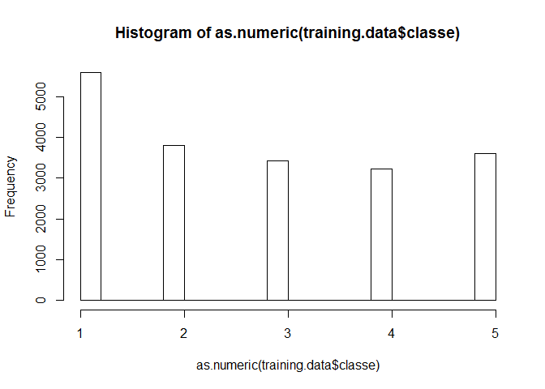

I load caret and divide the observations into a training set and a validation set:

```r
library(caret); set.seed(1)
inTrain = createDataPartition(training.data$classe, p = 0.8, list = F)
training.set = training.data[inTrain,]
validation.set = training.data[-inTrain,]
```

```r
train.control.cv = trainControl(method = "cv", number = 10)
lda.fit = train(classe ~ ., training.set, method = "lda", trainControl = train.control.cv)
```

[output not shown]

```r
lda.fit
```

```
## Linear Discriminant Analysis
##
## 15699 samples
##    55 predictor
##     5 classes: 'A', 'B', 'C', 'D', 'E'
##
## No pre-processing
## Resampling: Bootstrapped (25 reps)
## Summary of sample sizes: 15699, 15699, 15699, 15699, 15699, 15699, ...
## Resampling results:
##
##   Accuracy   Kappa
##   0.7326807  0.6612824
##
##
```

We see that the accuracy is approximately 0.73. I have tried doing these analysis with fewer variables (selected based on their importance in the random forest model below) but the results did not improve. I fit a random forest model. I use the randomForest library because it performs slightly faster than caret. There is no need for cross-validation to estimate the accuracy as it is seen from the out-of-bag performance.

```r
library(randomForest)       #faster than caret, still takes a while to run
rf.fit = randomForest(classe~., training.set, importance = T,
                        ntree = 500, mtry = 7)
rf.fit
```

```
##
## Call:
##  randomForest(formula = classe ~ ., data = training.set, importance = T,      ntree = 500, mtry = 7)
##                Type of random forest: classification
##                      Number of trees: 500
## No. of variables tried at each split: 7
##
##         OOB estimate of  error rate: 0.41%
## Confusion matrix:
##      A    B    C    D    E  class.error
## A 4462    2    0    0    0 0.0004480287
## B   11 3024    3    0    0 0.0046082949
## C    0   15 2719    4    0 0.0069393718
## D    0    0   20 2552    1 0.0081616790
## E    0    0    1    7 2878 0.0027720028
```

Finally, I estimate a model which uses boosting.

```r
boosting.grid = data.frame(n.trees = 1000,interaction.depth = 1,shrinkage = 0.01, n.minobsinnode = 10)
train.control.gbm = trainControl(method = "repeatedcv", number = 2,repeats = 1,
                                 verboseIter = FALSE,returnResamp = "all")
boosting.fit = train(classe ~ .,data = training.set,method = "gbm",
                     trControl = train.control.gbm,tuneGrid = boosting.grid, verbose = F)
boosting.fit #accuracy of 0.80 or so
```

```
## Stochastic Gradient Boosting
##
## 15699 samples
##    55 predictor
##     5 classes: 'A', 'B', 'C', 'D', 'E'
##
## No pre-processing
## Resampling: Cross-Validated (2 fold, repeated 1 times)
## Summary of sample sizes: 7850, 7849
## Resampling results:
##
##   Accuracy   Kappa
##   0.8178863  0.7695466
##
## Tuning parameter 'n.trees' was held constant at a value of 1000
##  1
## Tuning parameter 'shrinkage' was held constant at a value of
##  0.01
## Tuning parameter 'n.minobsinnode' was held constant at a value of 10
##
```

The accuracy of this model is about 82%. This model also takes a long time to run on my computer; for this reason, I only used 2-fold cross validation, and didn’t do a parameter space exploration.

Finally, I use the models on the validation set:

```r
lda.predictions = predict(lda.fit, validation.set)
rf.predictions = predict(rf.fit, validation.set)
boosting.predictions = predict(boosting.fit, validation.set)

confusionMatrix(lda.predictions, validation.set$classe)
```

```
## Confusion Matrix and Statistics
##
##           Reference
## Prediction   A   B   C   D   E
##          A 945 114  64  47  23
##          B  32 495  73  27 122
##          C  64 100 464  65  47
##          D  74  26  76 490  62
##          E   1  24   7  14 467
##
## Overall Statistics
##
##                Accuracy : 0.7293
##                  95% CI : (0.7151, 0.7431)
##     No Information Rate : 0.2845
##     P-Value [Acc > NIR] : < 2.2e-16
##
##                   Kappa : 0.657
##  Mcnemar's Test P-Value : < 2.2e-16
##
## Statistics by Class:
##
##                      Class: A Class: B Class: C Class: D Class: E
## Sensitivity            0.8468   0.6522   0.6784   0.7621   0.6477
## Specificity            0.9116   0.9197   0.9148   0.9274   0.9856
## Pos Pred Value         0.7921   0.6609   0.6270   0.6731   0.9103
## Neg Pred Value         0.9374   0.9168   0.9309   0.9521   0.9255
## Prevalence             0.2845   0.1935   0.1744   0.1639   0.1838
## Detection Rate         0.2409   0.1262   0.1183   0.1249   0.1190
## Detection Prevalence   0.3041   0.1909   0.1886   0.1856   0.1308
## Balanced Accuracy      0.8792   0.7859   0.7966   0.8447   0.8167
```

```r
confusionMatrix(rf.predictions, validation.set$classe)
```

```
## Confusion Matrix and Statistics
##
##           Reference
## Prediction    A    B    C    D    E
##          A 1114    3    0    0    0
##          B    1  755    5    0    0
##          C    0    1  677    7    0
##          D    0    0    2  635    1
##          E    1    0    0    1  720
##
## Overall Statistics
##
##                Accuracy : 0.9944
##                  95% CI : (0.9915, 0.9965)
##     No Information Rate : 0.2845
##     P-Value [Acc > NIR] : < 2.2e-16
##
##                   Kappa : 0.9929
##  Mcnemar's Test P-Value : NA
##
## Statistics by Class:
##
##                      Class: A Class: B Class: C Class: D Class: E
## Sensitivity            0.9982   0.9947   0.9898   0.9876   0.9986
## Specificity            0.9989   0.9981   0.9975   0.9991   0.9994
## Pos Pred Value         0.9973   0.9921   0.9883   0.9953   0.9972
## Neg Pred Value         0.9993   0.9987   0.9978   0.9976   0.9997
## Prevalence             0.2845   0.1935   0.1744   0.1639   0.1838
## Detection Rate         0.2840   0.1925   0.1726   0.1619   0.1835
## Detection Prevalence   0.2847   0.1940   0.1746   0.1626   0.1840
## Balanced Accuracy      0.9986   0.9964   0.9936   0.9933   0.9990
```

```r
confusionMatrix(boosting.predictions, validation.set$classe)
```

```
## Confusion Matrix and Statistics
##
##           Reference
## Prediction   A   B   C   D   E
##          A 989  88  23  37  22
##          B  31 582  42  15  60
##          C  30  59 601  65  46
##          D  51  27  15 505  29
##          E  15   3   3  21 564
##
## Overall Statistics
##
##                Accuracy : 0.8262
##                  95% CI : (0.8139, 0.8379)
##     No Information Rate : 0.2845
##     P-Value [Acc > NIR] : < 2.2e-16
##
##                   Kappa : 0.7799
##  Mcnemar's Test P-Value : < 2.2e-16
##
## Statistics by Class:
##
##                      Class: A Class: B Class: C Class: D Class: E
## Sensitivity            0.8862   0.7668   0.8787   0.7854   0.7822
## Specificity            0.9394   0.9532   0.9383   0.9628   0.9869
## Pos Pred Value         0.8533   0.7973   0.7503   0.8054   0.9307
## Neg Pred Value         0.9541   0.9446   0.9734   0.9581   0.9527
## Prevalence             0.2845   0.1935   0.1744   0.1639   0.1838
## Detection Rate         0.2521   0.1484   0.1532   0.1287   0.1438
## Detection Prevalence   0.2954   0.1861   0.2042   0.1598   0.1545
## Balanced Accuracy      0.9128   0.8600   0.9085   0.8741   0.8846
```

We see that the random forest model performs best, with 99.5% accuracy. The other models are significantly inferior.